# Vietnam Draft, Part 1

Updated: Tuesday, November 27, 2018 @ 02:02:53 PM

1. Create a boxplot to show the overall distribution of draft numbers. Calculate the mean, standard deviation, and five-number summary and display results in a tibble.

```r
summ1970 <- draft %>%
  summarize(mean = mean(num1970),
            stdv = sd(num1970),
            min  = fivenum(num1970)[1],
            Q1   = fivenum(num1970)[2],
            med  = fivenum(num1970)[3],
            Q3   = fivenum(num1970)[4],
            max  = fivenum(num1970)[5])
print.data.frame(summ1970)
```

```
   mean     stdv min Q1   med  Q3 max
1 183.5 105.7993   1 92 183.5 275 366
```

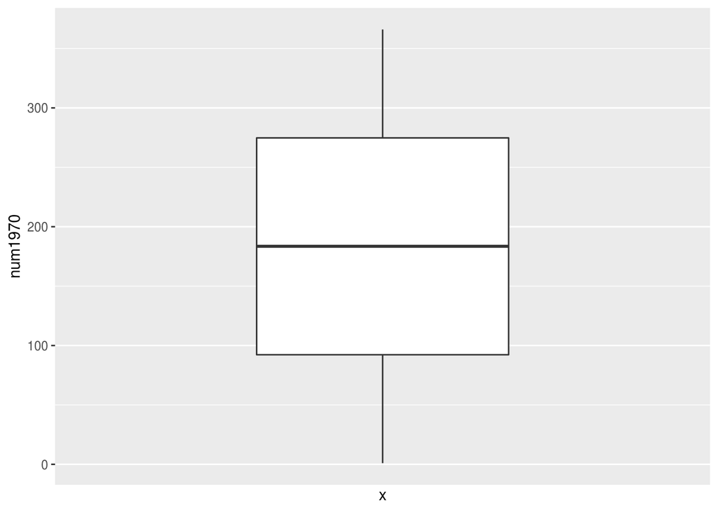

```r
ggplot(draft, aes(x = 1, y = num1970)) +
  geom_boxplot() +
  scale_x_discrete(breaks = NULL)
```

2. Create boxplots to compare the distributions of draft numbers by month (in order). Include a horizontal line to represent the overall mean draft number for 1970.

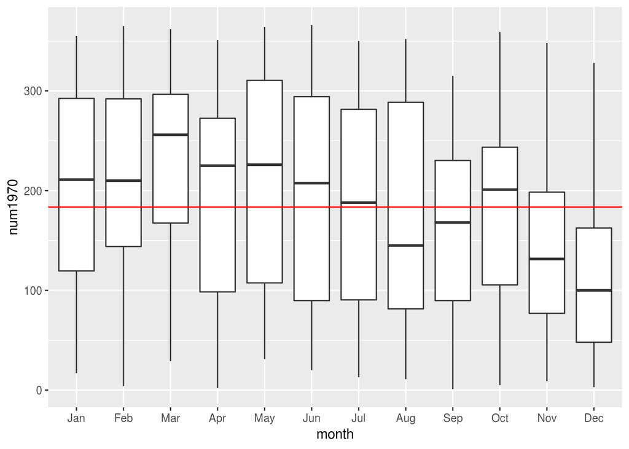

```r
draft <- draft %>%
  mutate(month = factor(month, levels = c("Jan",
                                          "Feb",
                                          "Mar",
                                          "Apr",
                                          "May",
                                          "Jun",
                                          "Jul",
                                          "Aug",
                                          "Sep",
                                          "Oct",
                                          "Nov",
                                          "Dec")))

ggplot(draft, aes(x = month, y = num1970)) +
  geom_boxplot() +
  geom_hline(yintercept = summ1970$mean, color = "red")
```

3. Create boxplots and density plots to compare the distributions of draft numbers by half-year. Calculate the mean, standard deviation, and five-number summary for both groups and display in a tibble.

```r
summ1970hy <- draft %>%
  group_by(halfyear) %>%
  summarize(mean = mean(num1970),
            stdv = sd(num1970),
            min  = fivenum(num1970)[1],
            Q1   = fivenum(num1970)[2],
            med  = fivenum(num1970)[3],
            Q3   = fivenum(num1970)[4],
            max  = fivenum(num1970)[5])
print.data.frame(summ1970hy)
```

```
  halfyear     mean     stdv min  Q1   med    Q3 max
1    First 206.3242 106.1437   2 112 216.5 299.0 366
2   Second 160.9239 100.7567   1  77 155.0 243.5 359
```

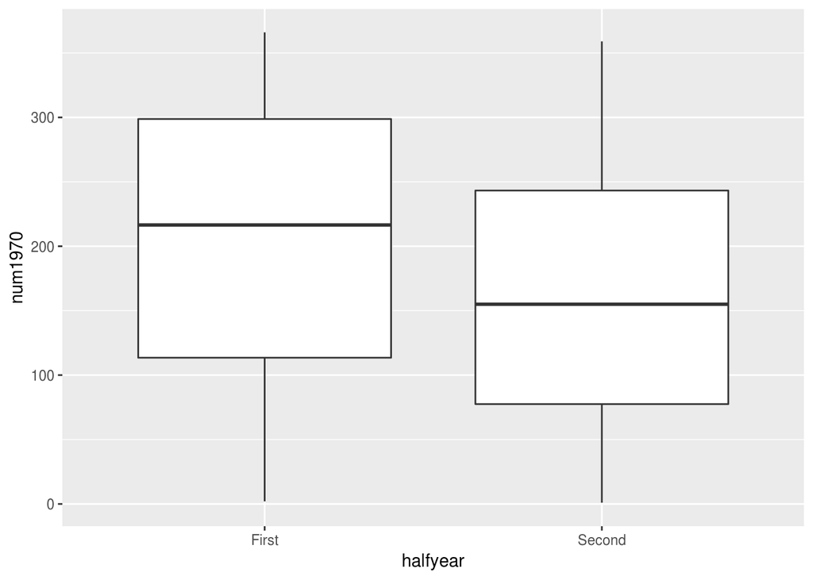

```r
ggplot(draft, aes(x = halfyear, y = num1970)) +
  geom_boxplot()
```

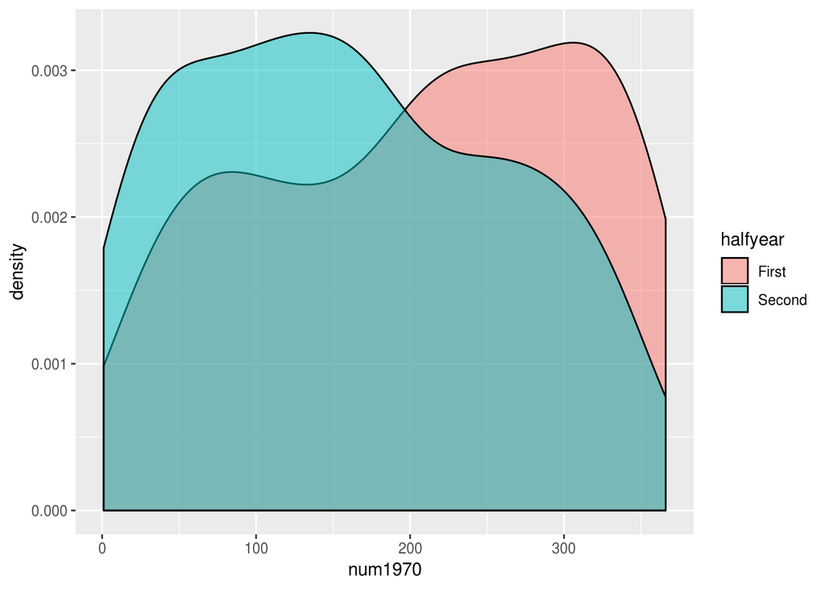

```r
ggplot(draft, aes(x = num1970, fill = halfyear)) +
  geom_density(alpha = 0.5)
```

4. In your opinion, what are two aspects of the physical process used to select the numbers in the 1970 draft lottery could cast doubt on the fairness of the results? How could they have impacted the randomness?

5. What information from your distribution analyses of the 1970 draft numbers could be used as evidence to cast doubt on the fairness of the results? Would the results be impossible in a fair lottery system?